# IODS course project

### New categorical variable: Crime

Now we will create a categorical variable of the crime rate in the Boston dataset (from the scaled crime rate). We will use the quantiles as the break points in the categorical variable, and will drop the old crime rate variable from the dataset. Also, we will divide the dataset to train and test sets, so that 80% of the data belongs to the train set.

```r
bins <- quantile(boston_scaled$crim)

# create a categorical variable 'crime'
crime <- cut(boston_scaled$crim, breaks = bins, include.lowest = TRUE, labels = c("low", "med_low", "med_high", "high"))

boston_scaled <- data.frame(boston_scaled, crime)

boston_scaled$crim<-NULL
```

```r
n <- nrow(boston_scaled)
# choose randomly 80% of the rows
ind <- sample(n,  size = nrow(boston_scaled) * 0.8)

# create train set
train <- boston_scaled[ind,]

# create test set
test <- boston_scaled[-ind,]

# save the correct classes from test data
correct_classes <- test$crime
```

## 3 | Linear discriminant analyses

Now we will tray to find a linear combination of variables that best separates the data into groups. By looking at the plot, we can see that accessibility to radial highways is the variable with the largest impact on LD1. For LD2, there are several variables with similar impacts. We can also see that Nox and Rad are almost perpendicular between them, which means that they do not have correlation.

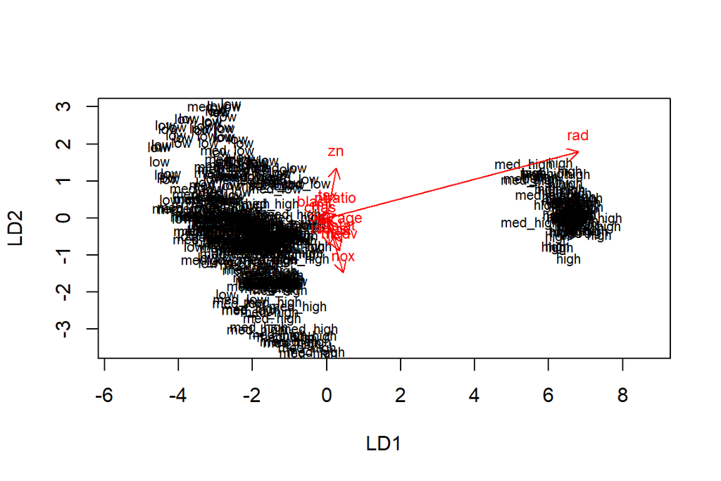

```r
lda.fit <- lda(crime ~ . , data = train)

lda.arrows <- function(x, myscale = 1, arrow_heads = 0.1, color = "red", tex = 0.75, choices = c(1,2)){
  heads <- coef(x)
  graphics::arrows(x0 = 0, y0 = 0,
         x1 = myscale * heads[,choices[1]],
         y1 = myscale * heads[,choices[2]], col=color, length = arrow_heads)
  text(myscale * heads[,choices], labels = row.names(heads),
       cex = tex, col=color, pos=3)
}

classes <- as.numeric(train$crime)

# plot the lda results (select both lines and execute them at the same time!)
plot(lda.fit, dimen = 2)
lda.arrows(lda.fit, myscale =2)
```

### Testing the prediction power of the model

Now, bu using the train and test datasets that we created before, we will assess the prediction power of this model. This will give us information regarding how well the model we used on the training data actually classifies the test data.

```r
correct_classes<-test$crime
test$crime<-NULL

# predict classes with test data
lda.pred <- predict(lda.fit, newdata = test)

# cross tabulate the results
table(correct = correct_classes, predicted = lda.pred$class)
```

```
##           predicted
## correct    low med_low med_high high
##   low       15       9        1    0
##   med_low    4      15        8    0
##   med_high   0       6       17    1
##   high       0       0        1   25
```